# Coursera: Practical Machine Learning - Project

Hariharan D

16 September 2017

### 1.Introduction

This project assignment is part of “Practical Machine Learning” course at Coursera’s “Data Science” specialization. Goal of this project is to use data from accelerometers on the belt, forearm, arm, and dumbell of 6 participants and obtain a prediction algorithm that correctly predicts the type of class (A to E), which is the **“classe”** variable in the training set. This project uses the “Weight Lifting Exercises” dataset. More information on this dataset is available **[here](http://groupware.les.inf.puc-rio.br/har)**.

Using devices such as Jawbone Up, Nike FuelBand, and Fitbit it is now possible to collect a large amount of data about personal activity relatively inexpensively. These type of devices are part of the quantified self movement - a group of enthusiasts who take measurements about themselves regularly to improve their health, to find patterns in their behavior, or because they are tech geeks. One thing that people regularly do is quantify **“how much”** of a particular activity they do, but they rarely quantify **“how well”** they do it.

Six young health participants were asked to perform one set of 10 repetitions of the Unilateral Dumbbell Biceps Curl in five different fashions: exactly according to the specification (Class A), throwing the elbows to the front (Class B), lifting the dumbbell only halfway (Class C), lowering the dumbbell only halfway (Class D) and throwing the hips to the front (Class E). Class A corresponds to the specified execution of the exercise, while the other 4 classes correspond to common mistakes.

Dataset will be analyzed using exploratory analysis and the following ML algorithms will be used to model the training datasets. Best one of the below three ML algorithms will be used for predictions in the test dataset.

1. Decision Tree
2. Random Forests
3. Generalized Boosted Regression

### 2.Data Source:

Dataset for this project is sourced from this **[website](http://groupware.les.inf.puc-rio.br/har)**

- Training Data is available here **pml-training.csv**
- Test Data is available here **pml-testing.csv**

### 3.Set Options and Load R Libraries

Set the chunk options.

```r
library(knitr)

knitr::opts_chunk$set(echo = TRUE, tidy = TRUE, warning = FALSE, message = FALSE, fig.align = "center")
```

Load the necessary libraries.

Note: It is assumed that the below libraries are aready installed.

```r
library(caret)
library(rpart)
library(rpart.plot)
library(rattle)
library(randomForest)
library(corrplot)
library(Rmisc)
library(ggplot2)
library(RColorBrewer)
```

### 4.Load Dataset and Clean the Data

Loading the dataset.

```r
set.seed(12345)

trainURL <- "https://d396qusza40orc.cloudfront.net/predmachlearn/pml-training.csv"

testURL <- "https://d396qusza40orc.cloudfront.net/predmachlearn/pml-testing.csv"

training <- read.csv(url(trainURL), na.strings = c("NA", "#DIV/0!", ""))

testing <- read.csv(url(testURL), na.strings = c("NA", "#DIV/0!", ""))

# Creating partition with Training dataset

trainData <- createDataPartition(training$classe, p = 0.7, list = FALSE)
trainingSet <- training[trainData, ]
testingSet <- training[-trainData, ]

dim(trainingSet)
```

```
## [1] 13737   160
```

```r
dim(testingSet)
```

```
## [1] 5885  160
```

Cleansing the data by removing “Near Zero Variance (NZV)”, “NA” and ID variables.

```r
# Removing 'NZV'

NZV <- nearZeroVar(trainingSet)
trainingSet <- trainingSet[, -NZV]
testingSet <- testingSet[, -NZV]

dim(trainingSet)
```

```
## [1] 13737   130
```

```r
dim(testingSet)
```

```
## [1] 5885  130
```

```r
# Removing 'NA'

dataNA <- sapply(trainingSet, function(x) mean(is.na(x))) > 0.95
trainingSet <- trainingSet[, dataNA == FALSE]
testingSet <- testingSet[, dataNA == FALSE]

dim(trainingSet)
```

```
## [1] 13737    59
```

```r
dim(testingSet)
```

```
## [1] 5885   59
```

```r
# Removing ID variables

trainingSet <- trainingSet[, -(1:5)]
testingSet <- testingSet[, -(1:5)]

dim(trainingSet)
```

```
## [1] 13737    54
```

```r
dim(testingSet)
```

```
## [1] 5885   54
```

### 5.Exploratory Analysis

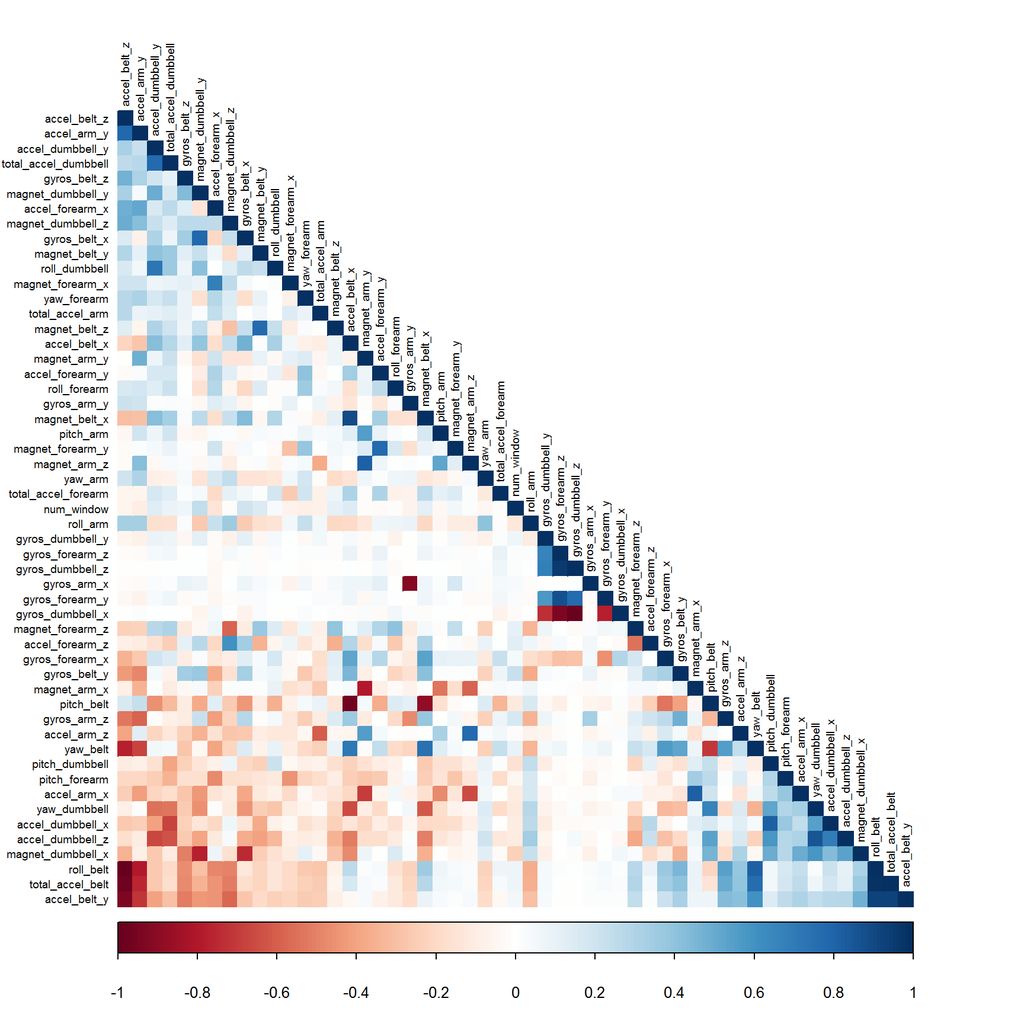

```r
# Correlation Analysis

corMatrix <- cor(trainingSet[, -54])
corrplot(corMatrix, order = "FPC", method = "color", type = "lower", tl.cex = 0.6,
    tl.col = rgb(0, 0, 0))
```

The highly correlated variables are shown in dark blue square fills in the correlation plot. Let us now verify the dataspread characteristics visually using GGPLOT.

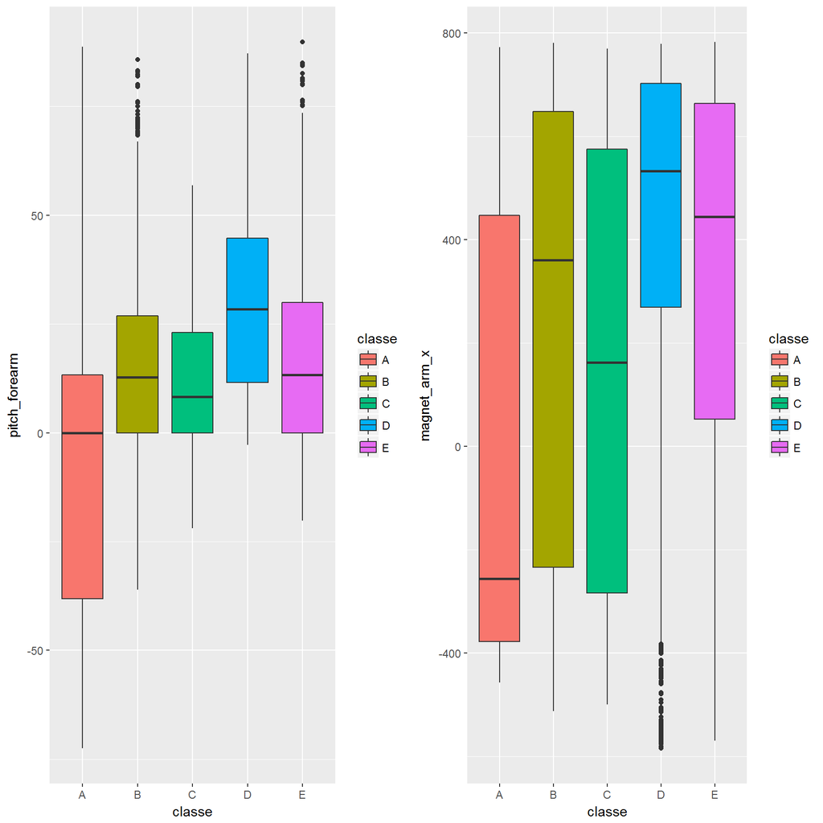

```r
# Multi-plot Analysis

p1 <- ggplot(trainingSet, aes(classe, pitch_forearm)) + geom_boxplot(aes(fill = classe))

p2 <- ggplot(trainingSet, aes(classe, magnet_arm_x)) + geom_boxplot(aes(fill = classe))

multiplot(p1, p2, cols = 2)
```

From the above plot, we can infer that there is no clear separation of classes.

### 6.Prediction Model - Machine Learning Algorithms

#### 6.1.Decision Tree

[figure not shown]

```r
# Model Fit

set.seed(12345)

fitDecisionTree <- rpart(classe ~ ., data = trainingSet, method = "class")
fancyRpartPlot(fitDecisionTree)
```

```r
# Prediction on Testing Dataset

predictDecisionTree <- predict(fitDecisionTree, newdata = testingSet, type = "class")
confMatDecisionTree <- confusionMatrix(predictDecisionTree, testingSet$classe)
confMatDecisionTree
```

```
## Confusion Matrix and Statistics
##
##           Reference
## Prediction    A    B    C    D    E
##          A 1530  269   51   79   16
##          B   35  575   31   25   68
##          C   17   73  743   68   84
##          D   39  146  130  702  128
##          E   53   76   71   90  786
##
## Overall Statistics
##
##                Accuracy : 0.7368
##                  95% CI : (0.7253, 0.748)
##     No Information Rate : 0.2845
##     P-Value [Acc > NIR] : < 2.2e-16
##
##                   Kappa : 0.6656
##  Mcnemar's Test P-Value : < 2.2e-16
##
## Statistics by Class:
##
##                      Class: A Class: B Class: C Class: D Class: E
## Sensitivity            0.9140  0.50483   0.7242   0.7282   0.7264
## Specificity            0.9014  0.96650   0.9502   0.9100   0.9396
## Pos Pred Value         0.7866  0.78338   0.7543   0.6131   0.7305
## Neg Pred Value         0.9635  0.89051   0.9422   0.9447   0.9384
## Prevalence             0.2845  0.19354   0.1743   0.1638   0.1839
## Detection Rate         0.2600  0.09771   0.1263   0.1193   0.1336
## Detection Prevalence   0.3305  0.12472   0.1674   0.1946   0.1828
## Balanced Accuracy      0.9077  0.73566   0.8372   0.8191   0.8330
```

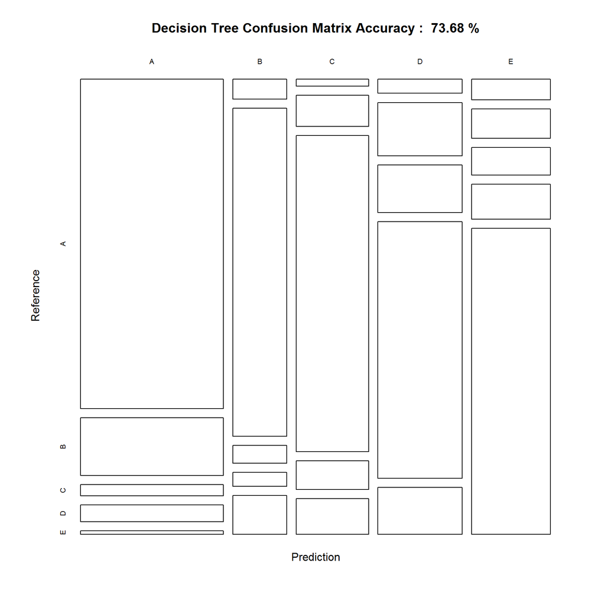

```r
# Plotting Confusion Matrix

plot(confMatDecisionTree$table, col = confMatDecisionTree$byClass, main = paste("Decision Tree Confusion Matrix Accuracy : ",
    round(confMatDecisionTree$overall["Accuracy"], 4) * 100, "%"))
```

#### 6.2. Random Forests

```r
# Model fit

set.seed(12345)

controlRF <- trainControl(method = "cv", number = 3, verboseIter = FALSE)
fitRandomForests <- train(classe ~ ., data = trainingSet, method = "rf", trControl = controlRF)
fitRandomForests$finalModel
```

```
##
## Call:
##  randomForest(x = x, y = y, mtry = param$mtry)
##                Type of random forest: classification
##                      Number of trees: 500
## No. of variables tried at each split: 27
##
##         OOB estimate of  error rate: 0.19%
## Confusion matrix:
##      A    B    C    D    E  class.error
## A 3904    1    0    0    1 0.0005120328
## B    6 2651    1    0    0 0.0026335591
## C    0    6 2390    0    0 0.0025041736
## D    0    0    8 2244    0 0.0035523979
## E    0    0    0    3 2522 0.0011881188
```

```r
# Prediction on Testing Dataset

predictRandomForests <- predict(fitRandomForests, newdata = testingSet)
confMatRandomForests <- confusionMatrix(predictRandomForests, testingSet$classe)
confMatRandomForests
```

```
## Confusion Matrix and Statistics
##
##           Reference
## Prediction    A    B    C    D    E
##          A 1674    5    0    0    0
##          B    0 1133    2    0    0
##          C    0    1 1024    7    0
##          D    0    0    0  957    4
##          E    0    0    0    0 1078
##
## Overall Statistics
##
##                Accuracy : 0.9968
##                  95% CI : (0.995, 0.9981)
##     No Information Rate : 0.2845
##     P-Value [Acc > NIR] : < 2.2e-16
##
##                   Kappa : 0.9959
##  Mcnemar's Test P-Value : NA
##
## Statistics by Class:
##
##                      Class: A Class: B Class: C Class: D Class: E
## Sensitivity            1.0000   0.9947   0.9981   0.9927   0.9963
## Specificity            0.9988   0.9996   0.9984   0.9992   1.0000
## Pos Pred Value         0.9970   0.9982   0.9922   0.9958   1.0000
## Neg Pred Value         1.0000   0.9987   0.9996   0.9986   0.9992
## Prevalence             0.2845   0.1935   0.1743   0.1638   0.1839
## Detection Rate         0.2845   0.1925   0.1740   0.1626   0.1832
## Detection Prevalence   0.2853   0.1929   0.1754   0.1633   0.1832
## Balanced Accuracy      0.9994   0.9972   0.9982   0.9960   0.9982
```

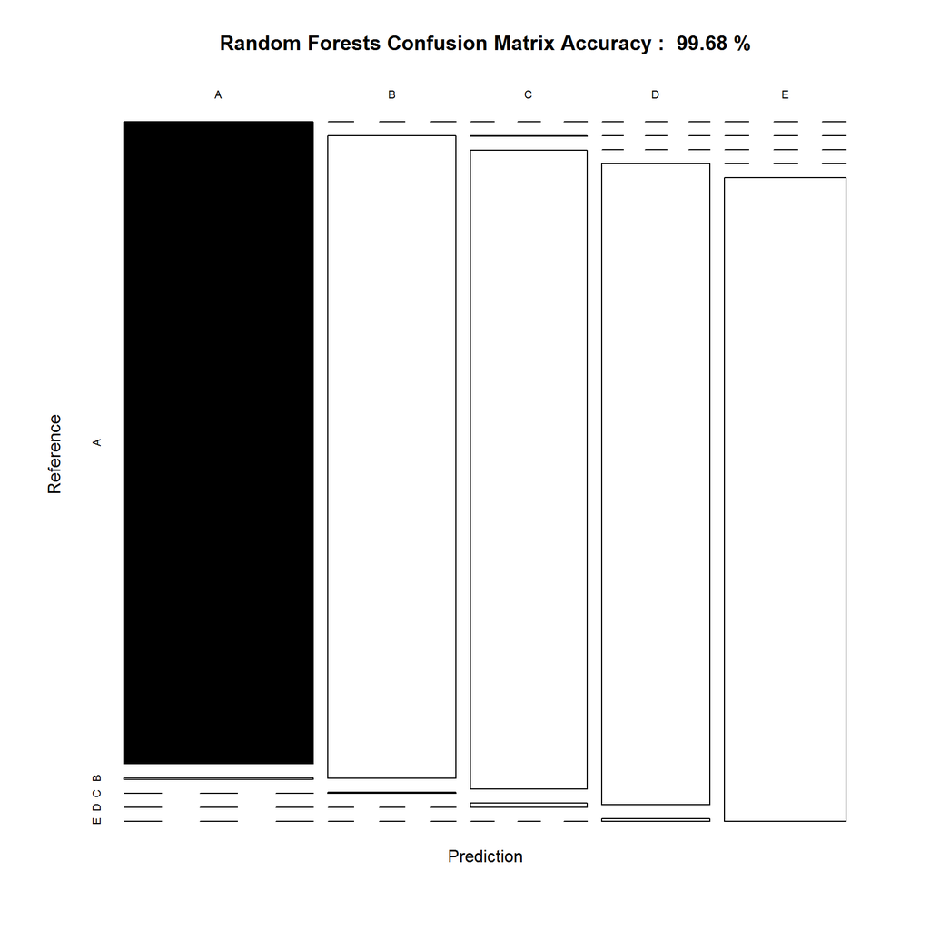

```r
# Plotting Confusion Matrix

plot(confMatRandomForests$table, col = confMatRandomForests$byClass, main = paste("Random Forests Confusion Matrix Accuracy : ",
    round(confMatRandomForests$overall["Accuracy"], 4) * 100, "%"))
```

#### 6.3. Generalized Boosted Regression

```r
# Model fit

set.seed(12345)

controlGBR <- trainControl(method = "repeatedcv", number = 5, repeats = 1)
fitGBR <- train(classe ~ ., data = trainingSet, method = "gbm", trControl = controlGBR,
    verbose = FALSE)
fitGBR$finalModel
```

```
## A gradient boosted model with multinomial loss function.
## 150 iterations were performed.
## There were 53 predictors of which 41 had non-zero influence.
```

```r
# Prediction on Testing Dataset

predictGBR <- predict(fitGBR, newdata = testingSet)
confMatGBR <- confusionMatrix(predictGBR, testingSet$classe)
confMatGBR
```

```
## Confusion Matrix and Statistics
##
##           Reference
## Prediction    A    B    C    D    E
##          A 1670   11    0    2    0
##          B    4 1115   16    5    2
##          C    0   12 1006   16    1
##          D    0    1    4  941   10
##          E    0    0    0    0 1069
##
## Overall Statistics
##
##                Accuracy : 0.9857
##                  95% CI : (0.9824, 0.9886)
##     No Information Rate : 0.2845
##     P-Value [Acc > NIR] : < 2.2e-16
##
##                   Kappa : 0.9819
##  Mcnemar's Test P-Value : NA
##
## Statistics by Class:
##
##                      Class: A Class: B Class: C Class: D Class: E
## Sensitivity            0.9976   0.9789   0.9805   0.9761   0.9880
## Specificity            0.9969   0.9943   0.9940   0.9970   1.0000
## Pos Pred Value         0.9923   0.9764   0.9720   0.9843   1.0000
## Neg Pred Value         0.9990   0.9949   0.9959   0.9953   0.9973
## Prevalence             0.2845   0.1935   0.1743   0.1638   0.1839
## Detection Rate         0.2838   0.1895   0.1709   0.1599   0.1816
## Detection Prevalence   0.2860   0.1941   0.1759   0.1624   0.1816
## Balanced Accuracy      0.9973   0.9866   0.9873   0.9865   0.9940
```

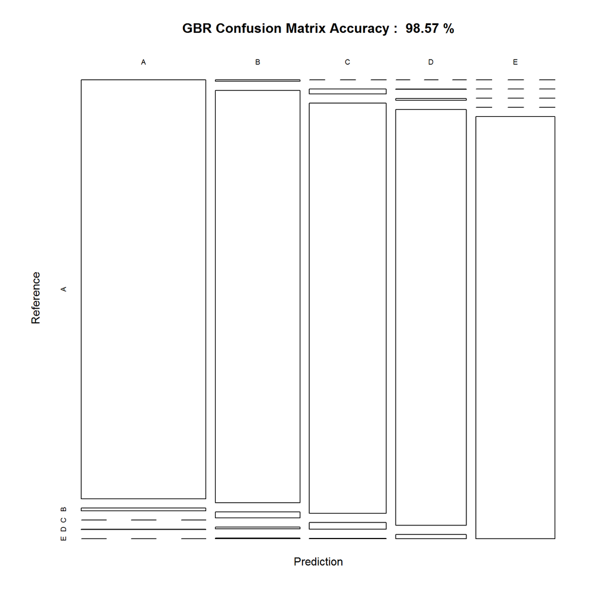

```r
# Plotting Confusion Matrix

plot(confMatGBR$table, col = confMatGBR$byClass, main = paste("GBR Confusion Matrix Accuracy : ",
    round(confMatGBR$overall["Accuracy"], 4) * 100, "%"))
```

### 7.Predicting Results on Test Dataset with Selected Model

The accuracy of above 3 Prediction Models are as follows;

1. Decision Tree: **73.68%**
2. Random Forests: **99.68%**
3. Generalized Boosted Regression: **98.57%**

The expected out-of-sample error of **Random Forests is 0.32%.**, which is least among all the above selected models. Hence Random Forests model will be used to predict the test dataset.

```r
# Predict Test Data

set.seed(12345)

predictTEST <- predict(fitRandomForests, newdata = testing)
predictTEST
```

```
##  [1] B A B A A E D B A A B C B A E E A B B B
## Levels: A B C D E
```